# RQ Answers

omitted

2024-04-05

# Data overview

```r
glimpse(all_data)
```

```
## Rows: 1,605
## Columns: 11
## $ repo                <chr> "opennlp", "opennlp", "opennlp", "opennlp", "openn…
## $ pr_number           <int> 153, 197, 207, 216, 216, 216, 216, 216, 240, 240, …
## $ rule                <chr> "java:S4973", "java:S112", "java:S1192", "java:S18…
## $ severity            <chr> "MAJOR", "MAJOR", "CRITICAL", "MAJOR", "MINOR", "C…
## $ file                <chr> "opennlp-tools/src/test/java/opennlp/tools/util/St…
## $ type                <chr> "BUG", "CODE_SMELL", "CODE_SMELL", "CODE_SMELL", "…
## $ status              <chr> "OPEN", "OPEN", "OPEN", "OPEN", "OPEN", "OPEN", "O…
## $ debt                <int> 5, 20, 10, 15, 5, 12, 2, 2, 8, 8, 5, 12, 10, 20, 2…
## $ ncloc_affected_file <int> 60, 23, 117, 32, 32, 32, 32, 32, 64, 64, 3, 132, 1…
## $ complexity          <int> 7, 4, 12, 5, 5, 5, 5, 5, 5, 5, 0, 18, 18, 18, 18, …
## $ origin              <chr> "NEW", "NEW", "PRE-EXISTING", "NEW", "NEW", "PRE-E…
```

# RQ1

## TDD (Technical Debt Density) by PR Distribution

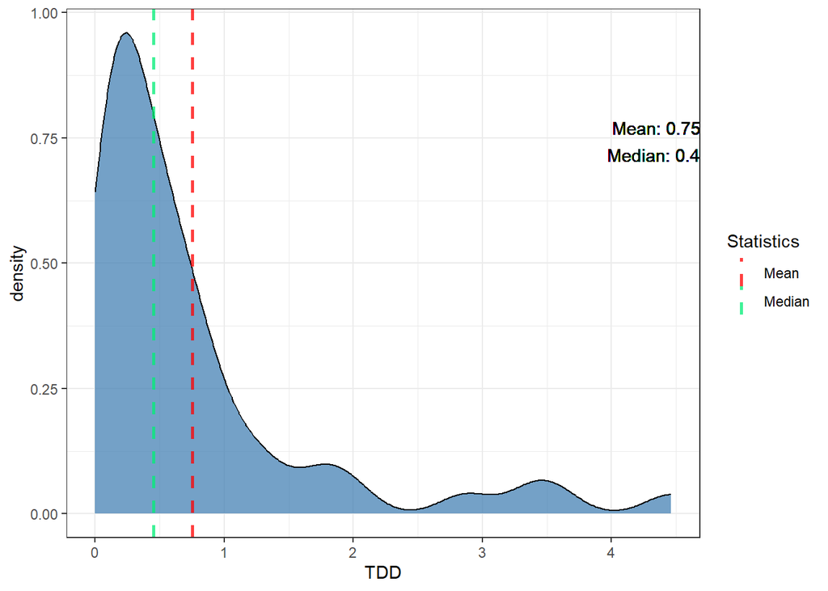

## TDV (Technical Debt Variation)

### TDV Distribution

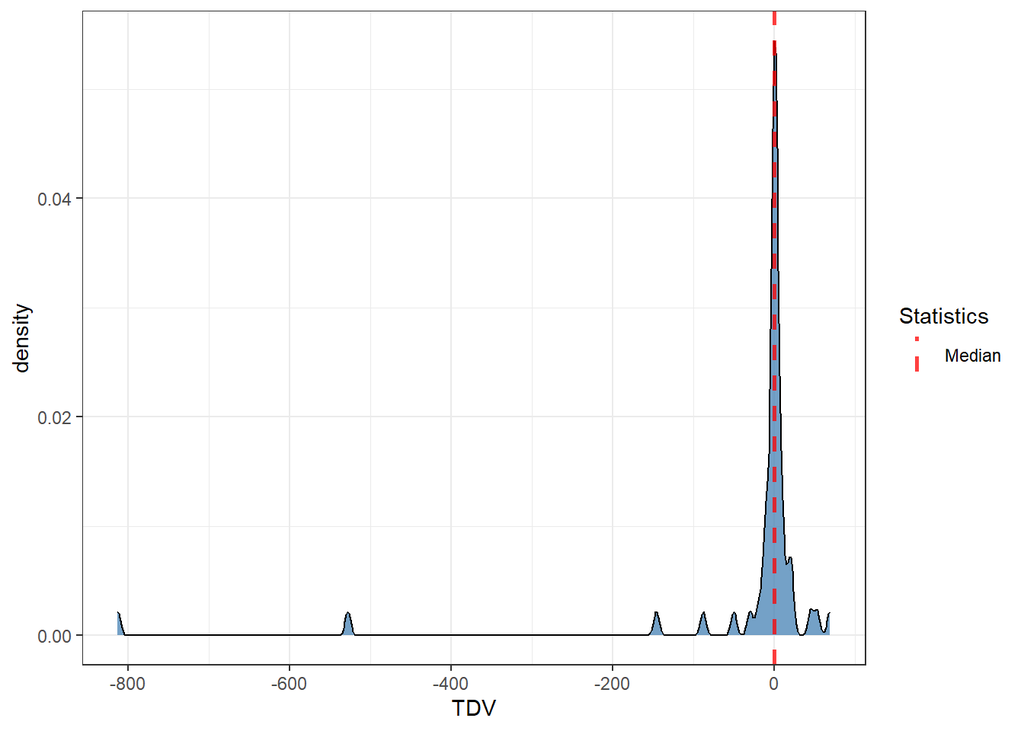

### Percentages for TDV < 0 (TD decrease), TDV = 0 (TD unchanged) and TDV > 0 (TD increased) by repo

| repo | tdv_lower_than_zero | tdv_equal_to_zero | tdv_greater_than_zero |
| --- | --- | --- | --- |
| opennlp | 26.92 | 38.46 | 34.62 |

### Mean of percentages of TDV (mean of repo percentages)

| mean_tdv_lower_than_zero | mean_tdv_equal_to_zero | mean_tdv_greater_than_zero |
| --- | --- | --- |
| 26.92 | 38.46 | 34.62 |

### Percentages of pre-existing TDV by repo

| repo | preexisting_tdv_equal_to_zero | preexisting_tdv_greater_than_zero |
| --- | --- | --- |
| opennlp | 64.58 | 35.42 |

## Mean of percentages of pre-existing TDV (mean of repo percentages)

| preexisting_tdv_equal_to_zero | mean_preexisting_tdv_greater_than_zero |
| --- | --- |
| 64.58 | 35.42 |

### Percentages for new TDV by repo

| repo | new_tdv_equal_to_zero | new_tdv_greater_than_zero |
| --- | --- | --- |
| opennlp | 96.15 | 3.85 |

## Mean of percentages of new TDV (mean of repo percentages)

| mean_new_tdv_equal_to_zero | mean_new_tdv_greater_than_zero |
| --- | --- |
| 96.15 | 3.85 |

## RQ2

As data is unbalanced across repositories, as shown in the issue characterization (../issues_characterization.Rmd), we will examine the top 10 fixed issues and the top 10 unfixed issues for each repository, and then aggregate them into a rank using the $PositionScore$ metric given by the following formula:

$PositionScore_{i} = \sum\limits_{j=1}^{k} Position_{j}$

given a rule $i$, its $PositionScore_{i}$ will be the sum of its position across all $k$ repositiries.After calculating the metrics for all rules, we rank them in a TOP 10 of the most frequent rules (fixed or unfixed, depending on the context) across repositories. The lower the PositionScore, the more frequent the rule across repositories.

### TOP 10 fixed per repo ranked by count

All top 10 fixed rules for each repo.

| rank | opennlp |
| --- | --- |
| 1 | java:S1854 - 54 |
| 2 | java:S112 - 33 |
| 3 | java:S1192 - 32 |
| 4 | java:S1130 - 26 |
| 5 | java:S1764 - 23 |
| 6 | java:S2095 - 18 |
| 7 | java:S3008 - 13 |
| 8 | java:S108 - 8 |
| 9 | java:S2200 - 8 |
| 10 | java:S1116 - 8 |

### TOP 10 fixed

TOP 10 fixed rules by PositionScore metric.

[output not shown]

### TOP 10 unfixed per repo ranked by count

All top 10 unfixed rules for each repo.

| rank | opennlp |
| --- | --- |
| 1 | java:S1854 - 373 |
| 2 | java:S1192 - 269 |
| 3 | java:S106 - 96 |
| 4 | java:S2095 - 85 |
| 5 | java:S1602 - 66 |
| 6 | java:S1135 - 35 |
| 7 | java:S112 - 27 |
| 8 | java:S1168 - 26 |
| 9 | java:S1874 - 26 |
| 10 | java:S1186 - 20 |

### TOP 10 unfixed

TOP 10 unfixed rules by PositionScore metric.

[output not shown]

# Outliers

## Higher TDD

| repo | pr_number | total_debt | total_ncloc | tdd |
| --- | --- | --- | --- | --- |
| opennlp | 563 | 1035 | 232 | 4.46120690 |
| opennlp | 569 | 1161 | 325 | 3.57230769 |
| opennlp | 585 | 1296 | 386 | 3.35751295 |
| opennlp | 559 | 665 | 232 | 2.86637931 |
| opennlp | 455 | 70 | 35 | 2.00000000 |
| opennlp | 487 | 69 | 38 | 1.81578947 |
| opennlp | 518 | 167 | 99 | 1.68686869 |
| opennlp | 423 | 160 | 118 | 1.35593220 |
| opennlp | 443 | 75 | 59 | 1.27118644 |
| opennlp | 216 | 36 | 32 | 1.12500000 |

[output cut: 42 more lines]

## Higher TDV

| pr_number | repo | tdv |
| --- | --- | --- |
| 487 | opennlp | 69 |
| 569 | opennlp | 53 |
| 585 | opennlp | 45 |
| 252 | opennlp | 22 |
| 197 | opennlp | 20 |
| 216 | opennlp | 20 |
| 522 | opennlp | 15 |
| 420 | opennlp | 10 |
| 421 | opennlp | 10 |
| 465 | opennlp | 10 |

[output cut: 42 more lines]

## Lower TDV

| pr_number | repo | tdv |
| --- | --- | --- |
| 431 | opennlp | -813 |
| 559 | opennlp | -528 |
| 466 | opennlp | -146 |
| 524 | opennlp | -88 |
| 502 | opennlp | -50 |
| 486 | opennlp | -30 |
| 471 | opennlp | -20 |
| 543 | opennlp | -15 |
| 414 | opennlp | -10 |
| 533 | opennlp | -10 |

[output cut: 42 more lines]

# Extra

## Number of PRs with pre-existing TD

| n |
| --- |
| 48 |

## Number of java:S1192 issues that affect test code

| n |
| --- |
| 301 |

## Number of java:S1192 issues that affect not test code

| n |
| --- |
| 0 |

## Summary NCLOC

```
##      ncloc
##  Min.   :  18.00
##  1st Qu.:  72.25
##  Median : 172.50
##  Mean   : 480.85
##  3rd Qu.: 281.00
##  Max.   :9275.00
```